# **Addition Insights - Companies to Watch Newsletter**

September 29, 2022

## **Jackpocket**

**Company:** Jackpocket  
**Country (Operating):** 145 West 45th Street, Floor 12, New York, NY 10036, United States  
**Founded Date:** January 01, 2013  
**Homepage:** https://jackpocket.com  
**Current Headcount:** 133  
**Lifetime Funding:** $199,599,999  
**Number of Funding Rounds:** 5  
**Investors:** David Chan, DCM Ventures, Elliott Bisnow, Evolution VC Partners, The Raine Group, Kamerra, Matthew Shampine, BRV Capital, Circle K, Engel Ventures, Rosepaul Investments / RosePaul Ventures, BRV Capital Management, Raine Ventures, M13 🚀, David Stern, Sand Hill Angels, Bullpen Capital, Fueled, HartBeat, Gannett.Partners, Grit Capital Partners, Conductive Ventures, TEGNA Ventures, Gaingels, Ro, NULL, Azoic Ventures, Inc., 840 Venture Partners, Transform Capital, Calm Ventures, 9Yards Capital, Left Lane Capital, Kevin Tung, Santa Barbara Venture Partners, Circle K Ventures, Digital Currency Group, Subversive Capital, Dennis Crowley, Private Ventures Group (“PVG”), CHASELLA, 7GC, BlueRun Ventures, David Blitzer, StepStone Group, Anchor Capital GP, Touchdown Ventures, Mark Cuban Companies, Kima Ventures, True Capital Management, TEGNA, Kevin W. Tung, Dhani Jones, Sean Hayes, Manny Machado, Jeffrey Berman, Kevin Hart, Gavin Isaacs, Mark Cuban  
**Most Recent Funding:** SERIES D - November 09, 2021  
**Sectors:** Gaming, SaaS, Consumer Software Services, Financial / Insurance Services  
**Description:** Jackpocket is on a mission to create a more convenient, fun, and responsible way to play the lottery. We are the first licensed third-party app in the U.S. that gives players an easy, secure way to order official state lottery tickets. Lottery players use Jackpocket to place orders for their favorite games, check lottery results, join lottery pools for better odds, and get automatic alerts when they win. Jackpocket players have won over $100 million in lottery prizes to date, including a $9.4 million jackpot won in NJ—the biggest mobile gaming win in U.S history. Jackpocket is available for lottery play in Arkansas, Colorado, Idaho, Minnesota, Montana, New Hampshire, New Jersey, New Mexico, New York, Ohio, Oregon, Texas, and Washington, D.C. with many new markets on the horizon. WE’RE HIRING! Come join our fun-loving, dedicated crew. View all open positions at: https://jackpocket.com/careers.

### **Headcount**

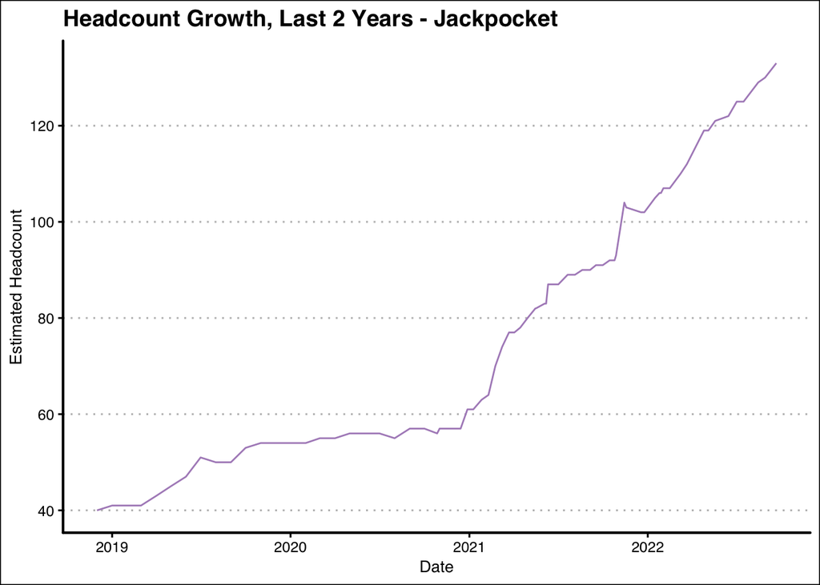

### **Revenue**

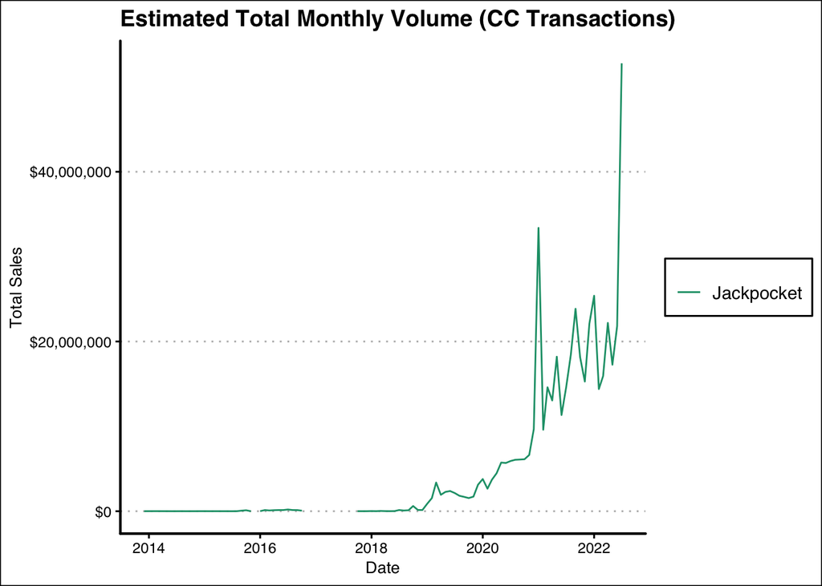

## **ClassWallet**

**Company:** ClassWallet  
**Country (Operating):** 6100 Hollywood Boulevard, Suite 108, Hollywood, FL 33024, United States  
**Founded Date:** January 01, 2011  
**Homepage:** https://classwallet.com  
**Current Headcount:** 53  
**Lifetime Funding:** $6,835,000  
**Number of Funding Rounds:** 5  
**Investors:** Kaplan Ventures, Kaplan EdTech Accelerator, Sinovation Ventures (创新工场), Cito Ventures, Edovate Capital, Novel Capital, Alpaca VC, Rainfall Ventures, Florida Funders, Techstars, NewSchools Venture Fund, Brentwood Associates, William Guttman  
**Most Recent Funding:** DEBT FINANCING - May 12, 2020  
**Sectors:** Financial Technology, Education, Financial / Insurance Services, Social / Civic / Gov Tech, Productivity / Collaboration, Education Tech  
**Description:** Founded in 2014, ClassWallet is the leading digital wallet and automated accounts payable platform for federal, state and district education. Saving valuable time and overhead costs to track, pay and report on decentralized purchases, ClassWallet is used in 27 states and by 19 state agencies, across 6,200 schools serving 4.1 million students. ClassWallet’s integrated marketplace of leading suppliers and learning curricula includes top retailers like Amazon, Office Depot, Staples, Scholastic, School Specialty, Lakeshore Learning and more. Headquartered in Miami, ClassWallet has been ranked number 779 on the prestigious Inc. 5000 list of the fastest-growing private companies in the U.S. in 2022 and the 56th fastest growing financial services company in the nation.

### **Headcount**

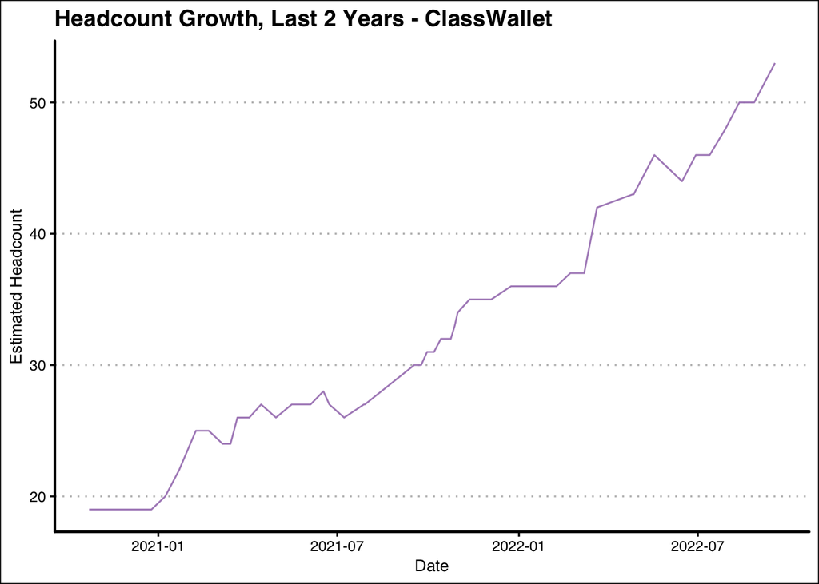

### **Revenue**

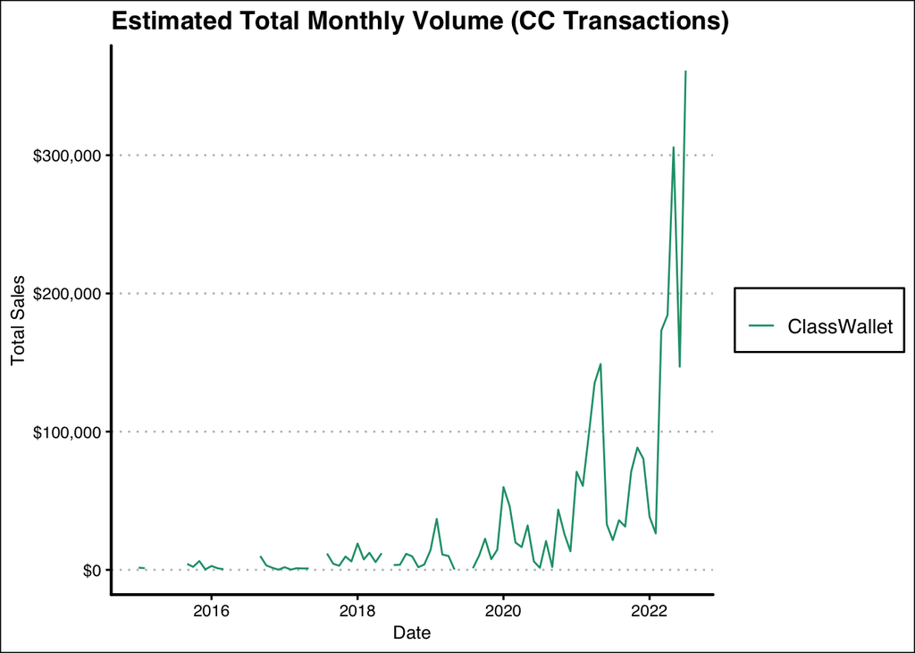

## **Fever**

**Company:** Fever  
**Country (Operating):** 379 West Broadway, 4th Floor, Suite 408, New York, NY 10012, United States  
**Founded Date:** January 01, 2014  
**Homepage:** https://feverup.com  
**Current Headcount:** 1556  
**Lifetime Funding:** $298,800,000  
**Number of Funding Rounds:** 7  
**Investors:** Rakuten Americas, Eight Roads, Solon Ventures, Portugal Ventures, Goodwater Capital, LABS, ATRESMEDIA, Vitruvian Partners, Nimble Ventures, Smash Capital, Caixa Capital, SCR, S.A., Carsten Boers, Convivialité Ventures, Eurazeo, Goldman Sachs Asset Management, 14W, Fidelity, Fidelity Investments, Goldman Sachs, Accel, Michael Zeisser, Alignment Growth, Pep Gomez, Bernardo Hernández, Jeff Pulver, Sergio Ramos  
**Most Recent Funding:** SERIES E - January 26, 2022  
**Sectors:** Consumer Software Services, Media / News / Entertainment  
**Description:** Fever is the leading global live-entertainment discovery tech platform with a clear mission: to democratize access to culture and entertainment. Fever has developed a proprietary technology that inspires its global community of over 125M people through personalized and curated experiences in their local city whilst empowering entertainment and event creators to reach new audiences and enhance their experiences. Some successful examples include the “Candlelight Concert Series” attended by over 3 million guests last year, the Los Angeles-based “Stranger Things: The Drive-Into Experience” co-produced with Netflix, or the “Van Gogh: The Immersive Experience” winner of USA Today’s 10 Best Readers Choice award. The company, present in over 100 major cities across the globe, is backed by leading investors such as Goldman Sachs, Alignment Growth (growth equity investor in global entertainment and consumer tech, led by former Warner Bros and Time Warner), Goodwater Capital (the largest dedicated consumer technology platform globally), Smash Capital (a late-stage venture capital firm led by former Disney and growth equity investors, backer of Epic Games), Eurazeo, Vitruvian Partners and Atresmedia among others. To pursue our objective, we are looking for bar-raisers who want to work hard, have fun, and make history with us.

### **Headcount**

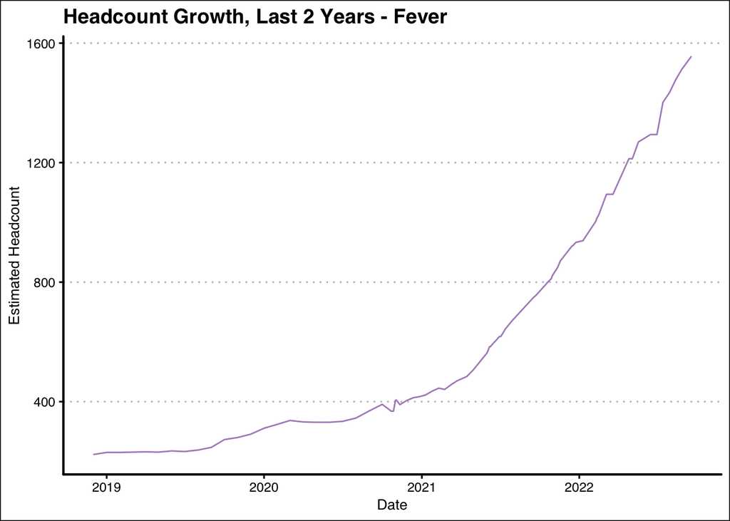

### **Revenue**

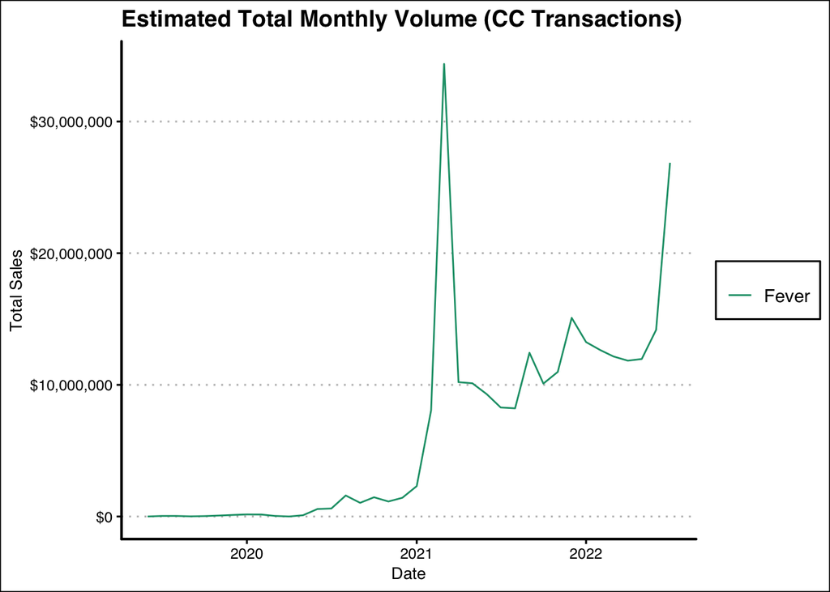

## **Bodily**

**Company:** Bodily  
**Country (Operating):** 53 Bridge Street, Unit 601, Brooklyn, New York, NY 11201, United States  
**Founded Date:** January 01, 2018  
**Homepage:** https://itsbodily.com  
**Current Headcount:** 19  
**Lifetime Funding:** $7,830,000  
**Number of Funding Rounds:** 2  
**Investors:** FJ Labs, Hearst, Nat Turner, Bridge Investments, Nueterra Capital  
**Most Recent Funding:** SERIES A1 - June 21, 2022  
**Sectors:** E-Commerce  
**Description:** Bodily is working to destigmatize female physiology and provide a modern experience for inadequately addressed areas of women’s health through evidence-based information and design-forward products that enable us to feel great in our bodies.

### **Headcount**

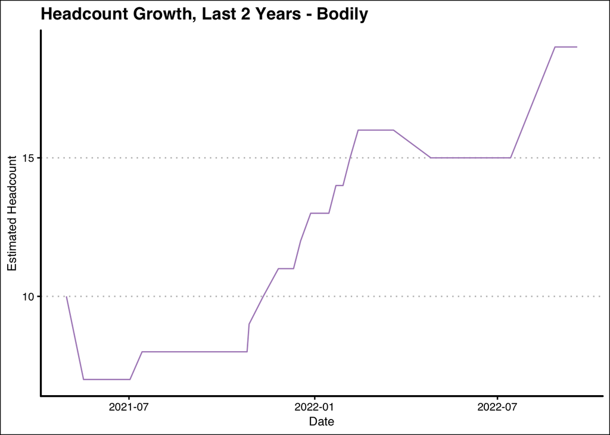

### **Revenue**

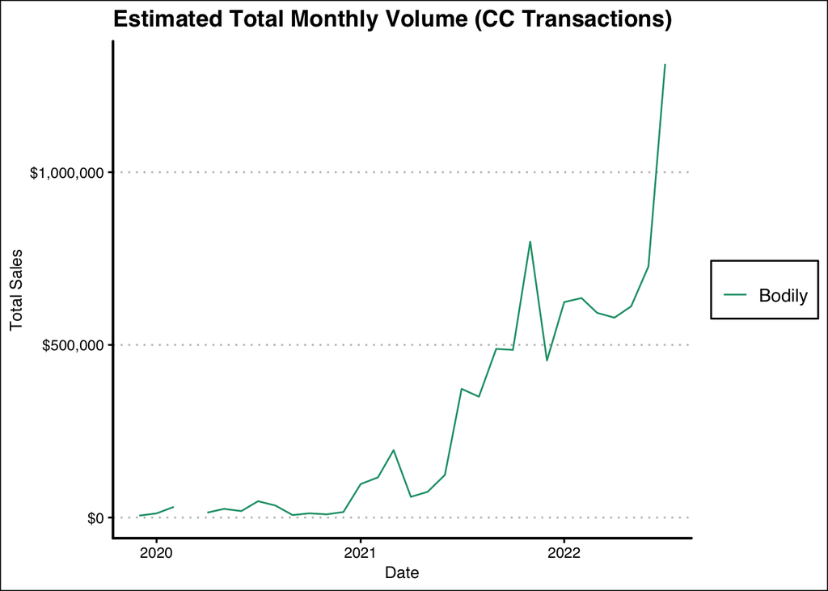

## **Embark Veterinary**

**Company:** Embark Veterinary  
**Country (Operating):** 320 Summer Street, Floor 6, Boston, MA 02110, United States  
**Founded Date:** January 01, 2015  
**Homepage:** https://embarkvet.com  
**Current Headcount:** 204  
**Lifetime Funding:** $82,300,000  
**Number of Funding Rounds:** 4  
**Investors:** SoftBank Investment Advisers, Section 32, Peak Opportunity Partners, AGO Partners, SV Angel, FJ Labs, Third Kind Venture Capital, Slow Ventures, Material, Founder Collective, F-Prime Capital, Eight Roads, Freestyle Capital, Jenny Lefcourt, Fabrice Grinda, Anne Wojcicki  
**Most Recent Funding:** SERIES B - July 26, 2021  
**Sectors:** Biotechnology, Education, Health / Wellness, Chemical / Life Sciences  
**Description:** Embark offers the most comprehensive, most accurate dog DNA test on the market. An Embark dog DNA test gives pet owners information about their dog’s breed, ancestry, health, and more — all with just a simple cheek swab. The company uses twice as much genetic information as any other test available and features the world’s only canine DNA relative finder. Pet owners can use Embark to test for over 210 genetic health conditions, so they can make the best choices for their dog. Launched by two brothers, Embark is an official research partner with Cornell University College of Veterinary Medicine and has a mission to end preventable disease in dogs.

### **Headcount**

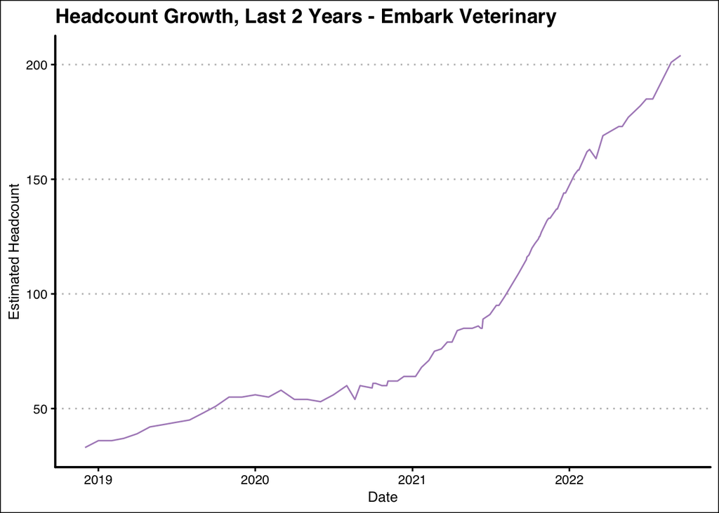

### **Revenue**

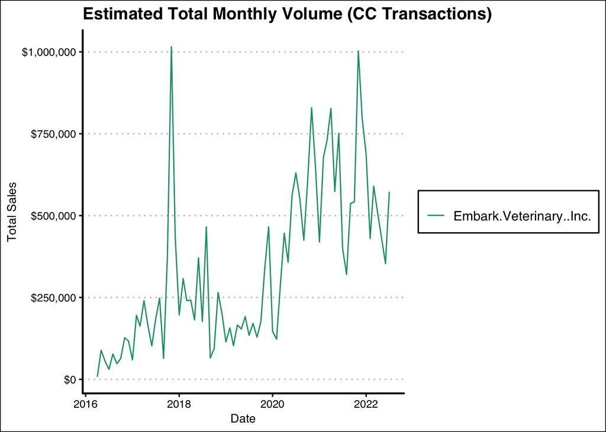

## **Spinn Inc.**

**Company:** Spinn Inc.  
**Country (Operating):** 1040 Mariposa Street, San Francisco, CA 94107, United States  
**Founded Date:** January 01, 2014  
**Homepage:** http://spinn.com  
**Current Headcount:** 45  
**Lifetime Funding:** $44,450,000  
**Number of Funding Rounds:** 6  
**Investors:** BABEL.Ventures, IDI Group LLC. , Spark Capital, Vernon & Park Capital, L.P., Bar 9 Ventures, Bar 9 Ventrues, Amazon Alexa Fund, 10X Capital, Highway1, Dick Kock, PCH International  
**Most Recent Funding:** SERIES B - January 10, 2022  
**Sectors:** Consumer Goods, Consumer Electronics  
**Description:** At Spinn® we know your morning cup of coffee is much more than an early morning beverage. It’s a ritual, a moment of tranquility, a daily treat for your taste buds. With that in mind, we’ve created a coffee maker to make your day a little easier and your coffee a lot better. Using only beans, no pods, capsules or filters we’ve engineered a coffee maker that creates zero environmental waste and uses centrifugal force to brew your morning cup. Whether you prefer drip, french press or an espresso, Spinn® is the coffee maker you’ve been waiting for. Our pre-order campaign is launching soon, but you can learn more at spinn.com

### **Headcount**

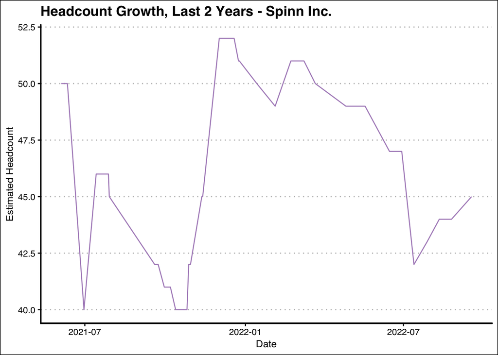

### **Revenue**

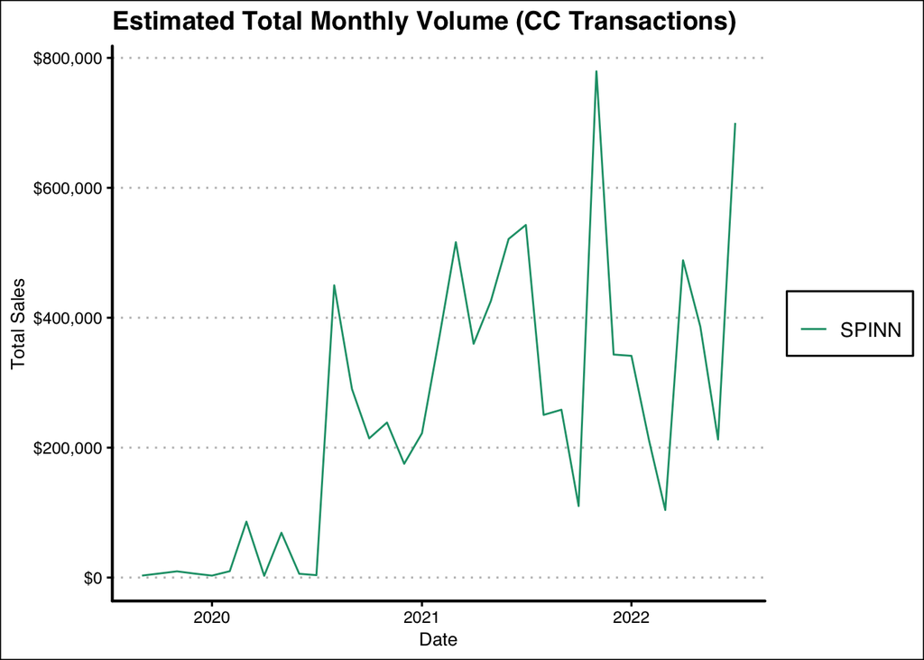

## **Sesame**

**Company:** Sesame  
**Country (Operating):** 427 Broadway, New York, NY 10013, United States  
**Founded Date:** January 01, 2018  
**Homepage:** https://sesamecare.com  
**Current Headcount:** 85  
**Lifetime Funding:** $75,000,000  
**Number of Funding Rounds:** 4  
**Investors:** Virgin, Valor Equity Partners, Atreides Management, LP, Industry Ventures, Coefficient Capital, TeleSoft Partners, Entrée Capital, Old Silver VC, Polaris Founders Capital, FMZ Ventures, General Catalyst, Alumni Ventures, Giant Ventures, GV  
**Most Recent Funding:** SERIES B - June 14, 2022  
**Sectors:** Financial Technology, Health / Nutritional Science, Financial / Insurance Services, Health / Wellness, Consumer Software Services  
**Description:** Sesame is building a radically new healthcare system for Americans who are uninsured or otherwise priced out of everyday care. Our marketplace replaces historically inefficient, expensive healthcare with a direct connection – either virtually or in-person – between patients and physicians. This direct connection enables Sesame to offer doctor visits, labs, imaging and prescription drugs at half the price. Our founders include a Harvard Ph.D. in health policy and economics; a former Goldman Sachs analyst; and entertainment executive and healthcare reformer David Goldhill, author of the legendary cover story in The Atlantic, “How American Health Care Killed My Father.” Sesame has raised $75 million so far from investors that include GV, Virgin Group and General Catalyst. The company was ranked #1 by Healthline for overall care in 2021 and 2022. For more information, please visit www.sesamecare.com.

### **Headcount**

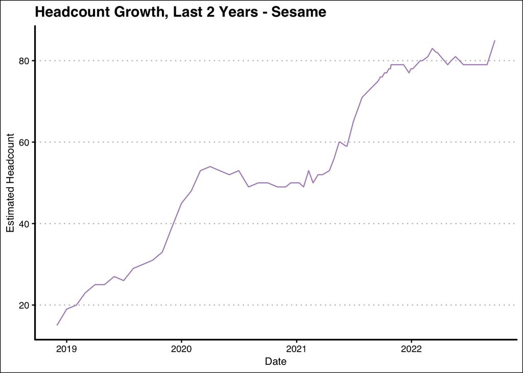

### **Revenue**

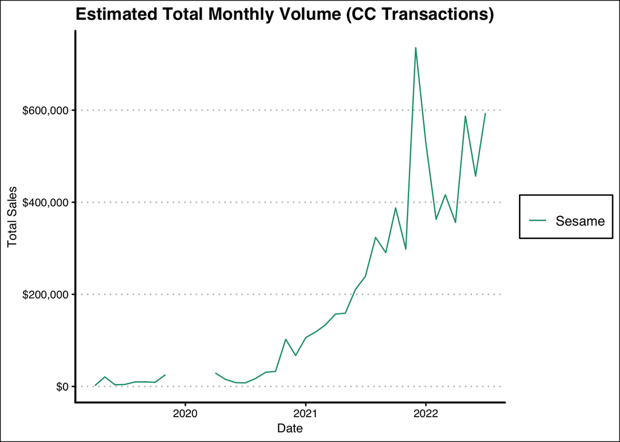